# a sprint through history toward computional notebooks

## Interactive Python

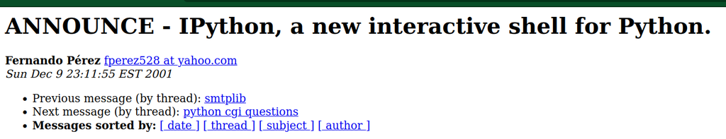

[IPython](https://mail.python.org/pipermail/python-list/2001-December/093408.html) grew to have a lot of features in a monolith

- an interactive shell
- a REPL protocol
- a notebook document fromat
- a notebook document conversion tool
- a web-based notebook authoring tool
- tools for building interactive UI (widgets)
- interactive parallel Python based on the above REPL protocol

## 2015 Project Jupyter The Big Split

Jupyter is like IPython, but language agnostic

```
<abbr title="julia">Ju</abbr>
<abbr title="python">py</abbr>
                   te
<abbr title="R">r</abbr>
```

jupyter enables [polyglot programming](https://gist.github.com/fperez/5b49246af4e340c37549265a90894ce6) in many languages at the same time.

```
## 2017 ACM Software System Award

<figure markdown="">
<figcaption>
jupyter is recognized as a critical systems software.

</figcaption>
<blockquote cite="https://awards.acm.org/software-system">

Jupyter has also gained wide industry adoption. Since 2015, Jupyter-based products have been released by several companies including Google (Cloud DataLab), Microsoft (AzureML, HDInsight), Intel (Trusted Analytics Platform), and IBM (IBM Watson Studio). Bloomberg and Anaconda Inc. have partnered with Project Jupyter to develop the next-generation web interface, JupyterLab.

</blockquote>
</figure>
<blockquote cite="https://blog.jupyter.org/jupyter-receives-the-acm-software-system-award-d433b0dfe3a2">

Similarly, there exist multiple client applications in addition to the Jupyter Notebook and JupyterLab to create and execute notebooks, each with its own use case and focus: the open source nteract project develops a lightweight desktop application to run notebooks; CoCalc, a startup founded by William Stein, the creator of SageMath, offers a web-based client with real-time collaboration that includes Jupyter alongside SageMath, LaTeX, and tools focused on education; and Google now provides Colaboratory, another web notebook frontend that runs alongside the rest of the Google Documents suite, with execution in the Google Cloud.

</blockquote>
```

## 2017 ACM Software System Award

jupyter is recognized as a critical systems software.

> Jupyter has also gained wide industry adoption. Since 2015, Jupyter-based products have been released by several companies including Google (Cloud DataLab), Microsoft (AzureML, HDInsight), Intel (Trusted Analytics Platform), and IBM (IBM Watson Studio). Bloomberg and Anaconda Inc. have partnered with Project Jupyter to develop the next-generation web interface, JupyterLab.

> Similarly, there exist multiple client applications in addition to the Jupyter Notebook and JupyterLab to create and execute notebooks, each with its own use case and focus: the open source nteract project develops a lightweight desktop application to run notebooks; CoCalc, a startup founded by William Stein, the creator of SageMath, offers a web-based client with real-time collaboration that includes Jupyter alongside SageMath, LaTeX, and tools focused on education; and Google now provides Colaboratory, another web notebook frontend that runs alongside the rest of the Google Documents suite, with execution in the Google Cloud.

```
## jupyter is in good company

<figure markdown="">
<figcaption markdown="">

Project Jupyter wins the 2017 ACM Software System Award, sharing a similar prestige as the Xerox Alto 30 years later.
</figcaption>
<iframe height="600" src="https://en.m.wikipedia.org/wiki/ACM_Software_System_Award#Recipients" width="100%"></iframe>
</figure>
```

## jupyter is in good company

Project Jupyter wins the 2017 ACM Software System Award, sharing a similar prestige as the Xerox Alto 30 years later.

[interactive chart not shown]

```
### there many notebook implementations and user interfaces

<figure markdown="">
<figcaption markdown="">

the notebook is a style of interface, collections of input forms and outputs repeated to weave a narrative and tangle code. there are open source and closed source options, along with language specific and agnostic implementations.

</figcaption>
<iframe height="600" src="https://en.m.wikipedia.org/wiki/Notebook_interface#Free/open-source_notebooks" width="100%"></iframe>
</figure>

with over [10 million notebooks][nbestimate], there are now large scale studies of notebook and literate computing interfaces:

* [Design and Use of Computational Notebooks](https://adamrule.com/files/dissertation/rule_dissertation.pdf)
* [Mapping the Landscape of Literate Computing](https://pure.au.dk/ws/files/173226224/PPIG_2019_camera_ready.pdf)
* [The Story in the Notebook: Exploratory Data Science using a Literate Programming Tool](https://marybethkery.com/projects/Verdant/Kery-The-Story-in-the-Notebook-Exploratory-Data-Science-using-a-Literate-Programming-Tool.pdf)

[nbestimate]: https://github.com/parente/nbestimate/blob/master/estimate.ipynb "a github project that estimates the number of notebooks on github"
```

### there many notebook implementations and user interfaces

the notebook is a style of interface, collections of input forms and outputs repeated to weave a narrative and tangle code. there are open source and closed source options, along with language specific and agnostic implementations.

[interactive chart not shown]

with over [10 million notebooks](https://github.com/parente/nbestimate/blob/master/estimate.ipynb), there are now large scale studies of notebook and literate computing interfaces:

- [Design and Use of Computational Notebooks](https://adamrule.com/files/dissertation/rule_dissertation.pdf)
- [Mapping the Landscape of Literate Computing](https://pure.au.dk/ws/files/173226224/PPIG_2019_camera_ready.pdf)
- [The Story in the Notebook: Exploratory Data Science using a Literate Programming Tool](https://marybethkery.com/projects/Verdant/Kery-The-Story-in-the-Notebook-Exploratory-Data-Science-using-a-Literate-Programming-Tool.pdf)

```
## notebooks and cells are increasingly more common forms

<figure markdown="">
<figcaption>Observable's description of notebooks and cells.</figcaption>
<blockquote cite="https://observablehq.com/@observablehq/notebooks-cells">
Observable is a platform for exploring data and code, visually, live in your browser. And <b>the central component of that platform is what we call a "notebook": an interactive, editable document defined by chunks of code called "cells".</b> Observable notebooks help you explore live data, prototype visualizations, make interactive art, understand algorithms, collaborate on reports, and much more. Join Anjana Vakil, Observable Developer Advocate, in diving into Observable and understanding the basic mechanics of working with notebooks &amp; cells.
</blockquote>
</figure>
<iframe allow="accelerometer; autoplay; clipboard-write; encrypted-media; gyroscope; picture-in-picture; web-share" allowfullscreen="" frameborder="0" height="315" src="https://www.youtube.com/embed/M1xMRkb89oM" title="Observable: Notebooks &amp; Cells" width="560"></iframe>
```

## notebooks and cells are increasingly more common forms

Observable's description of notebooks and cells.

> Observable is a platform for exploring data and code, visually, live in your browser. And **the central component of that platform is what we call a "notebook": an interactive, editable document defined by chunks of code called "cells".** Observable notebooks help you explore live data, prototype visualizations, make interactive art, understand algorithms, collaborate on reports, and much more. Join Anjana Vakil, Observable Developer Advocate, in diving into Observable and understanding the basic mechanics of working with notebooks & cells.

[video not shown]

```
## <abbr title="web content accessibility guidelines">WCAG</abbr>: we circumvented accessibility guidelines

<blockquote cite="https://en.wikipedia.org/wiki/Web_Content_Accessibility_Guidelines">

The **Web Content Accessibility Guidelines (WCAG)** are part of a series of web accessibility guidelines published by the Web Accessibility Initiative (WAI) of the World Wide Web Consortium (W3C), the main international standards organization for the Internet. They are a set of recommendations for making Web content more accessible, primarily for people with disabilities—but also for all user agents, including highly limited devices, such as mobile phones.
</blockquote>
<blockquote cite="https://www.boia.org/blog/history-of-the-web-content-accessibility-guidelines-wcag" markdown="">

### wcag drafts

* May 5, 1999: WCAG 1.0 is born. It included 14 guidelines, ranging from the need to provide text equivalents to considering clarity and simplicity on the web. Each guideline had between one and 10 supporting checkpoints.
* December 11, 2008: WCAG 2.0 broadens scope and offers the four principles. The early 2000s were years of unbelievable changes in technology, so WCAG evolved to keep up. WCAG 2.0 was an incredible follow-up to its predecessor and was intended to be applied to almost all things digital (including documents and apps). WCAG 2.0 also introduced the four guiding principles of accessibility, stating content must be perceivable, operable, understandable, and robust, supported by success criteria for meeting those principles. WCAG 2.0 reigned as the gold standard for a long time.
* June 5, 2018: WCAG 2.1 builds on but does not replace WCAG 2.0. The latest version of WCAG is backwards-compatible with the previous, which means if you comply with WCAG 2.1, you automatically comply with WCAG 2.0 — great news for website and app creators. WCAG 2.1 came as a highly-welcomed update, after the decade-old WCAG 2.0 could no longer completely account for advancements in technology and web use. The new WCAG 2.1 standards include several success criteria for improving web accessibility on mobile devices, as well as for people with low vision and cognitive disabilities.

</blockquote>
```